# Assignment 3

```python
# Import packages
import requests
import json
import jmespath
import pandas as pd
from pandas import DataFrame
import matplotlib.pyplot as plt
from collections import Counter
```

# Question 1

How many works have “artificial intelligence” in the title?

# Approach 1

To count works that have "artificial intelligence" in the title, I first constructed a query URL that retrieves all works containing "artificial intelligence" in their titles. I then used the requests to send the query and obtain the results in json format.

Based on the json document, I can count the results from meta field. I stored the results which include all works with "artificial intelligence" in the title for future reference.

```python
# Search for all the works that have "artificial intelligence" in the title
url = "https://api.openalex.org/works?filter=title.search:artificial%20intelligence"
# convert to json file
search_results = requests.get(url).json()

# Count how many works have "artificial intelligence" in the title
count_ai = search_results['meta']['count']

# Save the json file
with open('AI_search_results.json', 'w') as file:
    file.write(json.dumps(search_results, indent =4))

count_ai
```

```
198481
```

# Answer 1

Based on the api searching results, there are **198,481** works with “artificial intelligence” in the title on OpenAlex.

# Question 2

Filter years since 2020 and group by the country of the author’s affiliation. Produce a table which sorts the countries by number of publications about artificial intelligence.

# Approach 2

I wrote a URL query and parameters that filter works containing “artificial intelligence” in the title and were published after 2020. I also grouped the works by the country of the authors’ institutions so that the OpenAlex API would automatically aggregate publications by country. This allowed me to count the number of AI-related works for each country.

Finally, I converted the results into a DataFrame and sorted them in descending order by the number of publications.

```python
# Filter works after 2020 and include "artificial intelligence" in the title
url2 = "https://api.openalex.org/works"
params = {
    "filter": "title.search:artificial intelligence,from_publication_date:2020-01-01",
    "group_by": "institutions.country_code",
    "per_page": 200,
    "page": 1
}

# Creat an empty list to store group_by results
results_ai_2020 = []

# set two conditions for the while loop
has_more_pages = True
maxpagesnot_reached = True

# Look through pages
while has_more_pages and maxpagesnot_reached:
    response = requests.get(url2, params=params).json()
    # Extract the 'group_by' results from the API response
    group_results = response.get("group_by", [])
    results_ai_2020.extend(group_results)

    # If the number of results equals 'per_page', assume there may be more pages
    per_page = response['meta']['per_page']
    has_more_pages = (len(group_results) == per_page)
    # Limit the loop to 100 pages maximum
    maxpages_notreached = (params['page'] <= 100)

    # If both conditions are satisfied, request the next page
    if has_more_pages and maxpagesnot_reached:
        params["page"] += 1

# save the json file
with open('results_ai_2020.json', 'w') as file:
    file.write(json.dumps(results_ai_2020, indent =4))

# Convert the group_by results into a dataframe
# Sort by number of publications
country_counts = pd.DataFrame(results_ai_2020)
country_counts.columns = ["url", "country", "num_publications"]
country_counts = country_counts.sort_values(by="num_publications", ascending=False)
country_counts
```

|  | url | country | num_publications |
| --- | --- | --- | --- |
| 0 | https://openalex.org/countries/US | United States of America | 20224 |
| 1 | https://openalex.org/countries/CN | China | 15752 |
| 2 | https://openalex.org/countries/IN | India | 11160 |
| 3 | https://openalex.org/countries/GB | United Kingdom of Great Britain and Northern I... | 6812 |
| 4 | https://openalex.org/countries/IT | Italy | 4128 |
| ... | ... | ... | ... |
| 188 | https://openalex.org/countries/GL | Greenland | 1 |
| 189 | https://openalex.org/countries/GN | Guinea | 1 |
| 190 | https://openalex.org/countries/HT | Haiti | 1 |
| 191 | https://openalex.org/countries/NC | New Caledonia | 1 |
| 192 | https://openalex.org/countries/WS | Samoa | 1 |

193 rows × 3 columns

# Answer 2

Based on the table, we can see that the **United States of America** has the largest number of published works with “artificial intelligence” in the title, which is **20,224**, followed by **China** with **15,752** publications and **India** with **11,160**. It should also be noted that the results do not include works for which the country code is missing.

# Question 3

What are the names of the 10 most highly cited papers on artificial intelligence since 2020? How many citations do they have? What are the authors? What institutions are they affiliated with?

# Approach 3

I wrote a URL query that filters for works containing “artificial intelligence” in the title, published after 2020, and sorted them by citation count in descending order. I limited the results to the top ten works. The response was stored in json format.

To extract information including titles, citations, author names and institutions, I wrote a nested loop that retrieved each work’s data. I converted the extracted information into a DataFrame and produced a table summarizing the ten most cited works.

```python
# Filter works with "artificial intelligence" in the title,
# published after 2020, sorted by citation count, display top 10
url2020cite = "https://api.openalex.org/works?filter=title.search:artificial%20intelligence,from_publication_date:2020-01-01&sort=cited_by_count:desc&per_page=10"

# Send request and store in json format
cite_ai_2020 = requests.get(url2020cite).json()

# Extract the list of works
works10 = cite_ai_2020["results"]

# Create an empty list to store extracted information
list_10 = []

# Extract information of title, number of citations, authors, and institutions
for work in works10:
    title = work.get("title", "")
    citations = work.get("cited_by_count", 0)

    # Create lists for authors and institutions
    authors = []
    institution = []
    # Extract author names from authorships
    for authorship in work.get("authorships", []):
        authorname = authorship.get("author", {}).get("display_name", "")
        if authorname:
            authors.append(authorname)

        # For institutions, I will extract the institution names and the countries
        for ins in authorship.get("institutions", []):
            affiliation = ins.get("display_name", "")
            country_code = ins.get("country_code", "")
            if affiliation:
                institution.append(f"{affiliation}, {country_code}")

    # Store extracted information in list_10
    list_10.append({
        "title": title,
        "citations": citations,
        # Join multiple authors and institutions for each works
        "author": "; ".join(authors),
        "institutions": "; ".join(institution)
    })

# Convert to a dataframe
data10 = pd.DataFrame(list_10)
# Display dataframe
data10
```

|  | title | citations | author | institutions |
| --- | --- | --- | --- | --- |
| 0 | Artificial Intelligence in Education: A Review | 2267 | Lijia Chen; Pingping Chen; Zhijian Lin | Yango University, CN; Fuzhou University, CN; F... |
| 1 | The role of artificial intelligence in achievi... | 2195 | Ricardo Vinuesa; Hossein Azizpour; Iolanda Lei... | Swedish e-Science Research Centre, SE; KTH Roy... |
| 2 | Using Artificial Intelligence to Detect COVID-... | 1956 | Lin Li; Lixin Qin; Zeguo Xu; Youbing Yin; Xin ... | Jianghan University, CN; Wuhan Pulmonary Hospi... |
| 3 | Revolutionizing healthcare: the role of artifi... | 1629 | Shuroug A. Alowais; Sahar S. Alghamdi; Nada Al... | King Saud bin Abdulaziz University for Health ... |
| 4 | Comparing Physician and Artificial Intelligenc... | 1576 | John W. Ayers; Adam Poliak; Mark Dredze; Eric ... | University of California, San Diego, US; Qualc... |
| 5 | A Survey on Explainable Artificial Intelligenc... | 1560 | Erico Tjoa; Cuntai Guan | Alibaba Group (China), CN; Nanyang Technologic... |
| 6 | Human Trust in Artificial Intelligence: Review... | 1419 | Ella Glikson; Anita Williams Woolley | Bar-Ilan University, IL; Carnegie Mellon Unive... |
| 7 | Artificial Intelligence (AI) applications for ... | 1416 | Raju Vaishya; Mohd Javaid; Ibrahim Haleem Khan... | Indraprastha Apollo Hospitals, IN; Jamia Milli... |
| 8 | Photonics for artificial intelligence and neur... | 1399 | Bhavin J. Shastri; Alexander N. Tait; Thomas F... | Queen's University, CA; Princeton University, ... |
| 9 | Review of Artificial Intelligence Techniques i... | 1396 | Feng Shi; Jun Wang; Jun Shi; Ziyan Wu; Qian Wa... | United Imaging Healthcare (China), CN; Shangha... |

# Answer 3

The table above summarizes the titles, citation counts, authors, and institutions of the top ten most cited works.

For example, the most cited work is *Artificial Intelligence in Education: A Review* by Lijia Chen, Pingping Chen, and Zhijian Lin, which has a total of **2,267** citations. The second most cited work is *The Role of Artificial Intelligence in Achieving the Sustainable Development Goals*, with **2,195** citations. This is followed by *Using Artificial Intelligence to Detect COVID-19 and Community-acquired Pneumonia Based on Pulmonary CT: Evaluation of the Diagnostic Accuracy*, which has **1,956** citations.

# Question 4

How has the number of publications with the word “artificial intelligence” changed year- to-year since 2000? How does this compare to the usage of the word “LLM” or “GPT”? Do the analysis for another keyword of your interest. Plot your results in a graph.

# Approach 4

To compare the publication trends after 2000, I wrote three URL queries that filter for works have “artificial intelligence”, “LLM”, and “GPT” in the text and that were published after 2000. For each query, I added the parameter group_by=publication_year so that the OpenAlex API would aggregate the results by year and return the number of publications.

I then converted the group_by field from each json response into a DataFrame and sorted the years. I plotted the publication trends for each keyword separately to see the trend and combined them into a single figure to compare the overall patterns.

*It should be noticed that we are looking at papers including "artificial intelligence", "LLM", "GPT" in their text, not just in the title.*

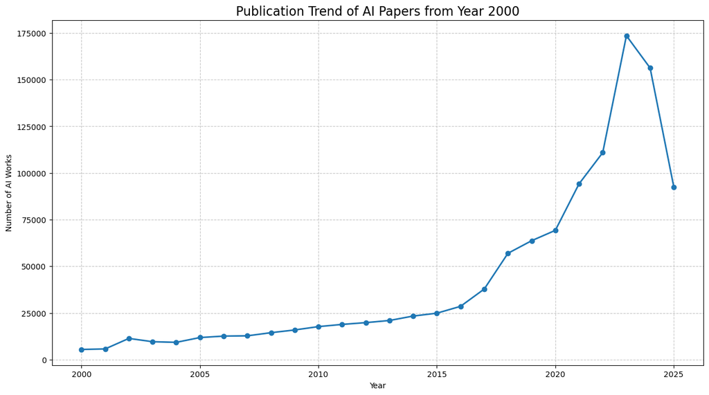

```python
# Filter for works related to artificial intelligence and was published after 2000
# aggregate by publication year
# Store the data in json format
url_ai = "https://api.openalex.org/works?filter=from_publication_date:2000-01-01&search=artificial intelligence&group_by=publication_year"
search_ai = requests.get(url_ai).json()

# Save the json file
with open('search_ai.json', 'w') as file:
    file.write(json.dumps(search_ai, indent =4))

# Extract grouped data from json responsee
group_by_year = search_ai["group_by"]

# Convert to a dataframe
# rename columns
# make sure "year" is numeric
# sort by year
year_counts = pd.DataFrame(group_by_year)
year_counts = year_counts.rename(columns={"key": "year", "count": "num_publications"})
year_counts["year"] = pd.to_numeric(year_counts["year"])
year_counts = year_counts.sort_values("year")

# Plot the publication trend over time
plt.figure(figsize=(15, 8))
plt.plot(year_counts["year"], year_counts["num_publications"], marker="o", linewidth=2)
plt.xlabel("Year")
plt.ylabel("Number of AI Works")
plt.title("Publication Trend of AI Papers from Year 2000", fontsize=16)
plt.grid(True, linestyle="--", alpha=0.7)
plt.show()
```

**Publication Trend of AI Papers from Year 2000**

This figure shows the publication trend of papers mentioning AI. We found that from 2000 to 2015, the number of AI-related papers increased steadily. But after 2016, the number of publications increased rapidly, surging in 2022 and reaching a peak of around 175,000 publications at 2023. A slight decline appears in the following years, but the decrease observed in 2025 is most likely due to incomplete indexing, as many papers from this year may not yet have been collected or published.

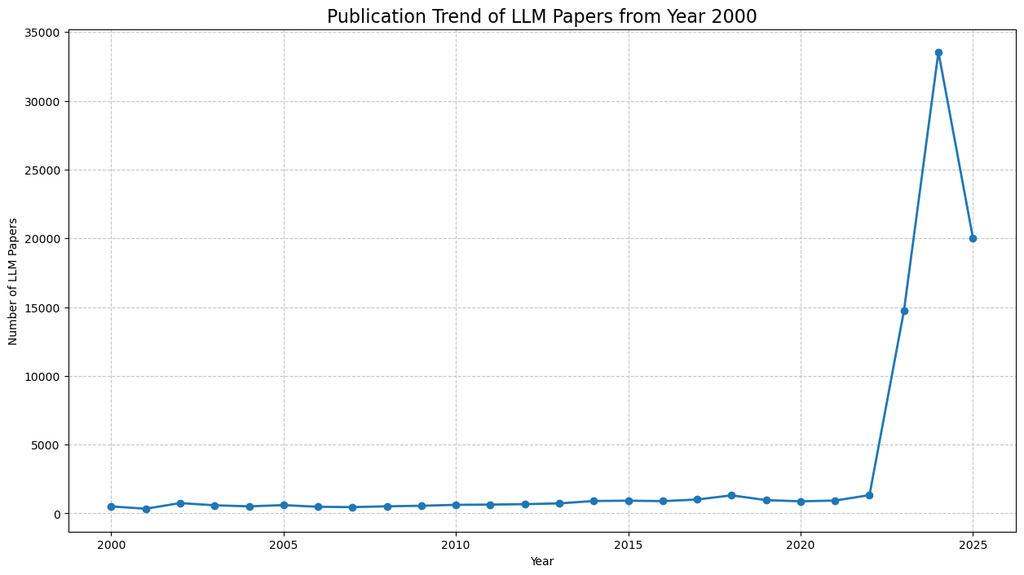

```python
# Filter for works related to LLM and was published after 2000
# aggregat by publication year
# Store the data in json format
url_llm = "https://api.openalex.org/works?filter=from_publication_date:2000-01-01&search=llm&group_by=publication_year"
search_llm = requests.get(url_llm).json()

# Save the json file
with open('search_llm.json', 'w') as file:
    file.write(json.dumps(search_llm, indent =4))

# Extract grouped data from json response
group_year_llm = search_llm["group_by"]

# Convert to a dataframe
# rename columns
# make sure "year" is numeric
# sort by year
year_llm = pd.DataFrame(group_year_llm)
llm_counts = year_llm.rename(columns={"key": "year", "count": "num_publications"})
llm_counts["year"] = pd.to_numeric(llm_counts["year"])
llm_counts = llm_counts.sort_values("year")

# Plot the publication trend over time
plt.figure(figsize=(15, 8))
plt.plot(llm_counts["year"], llm_counts["num_publications"], marker="o", linewidth=2)
plt.xlabel("Year")
plt.ylabel("Number of LLM Papers")
plt.title("Publication Trend of LLM Papers from Year 2000", fontsize=16)
plt.grid(True, linestyle="--", alpha=0.7)
plt.show()
```

**Publication Trend of LLM Papers from Year 2000**

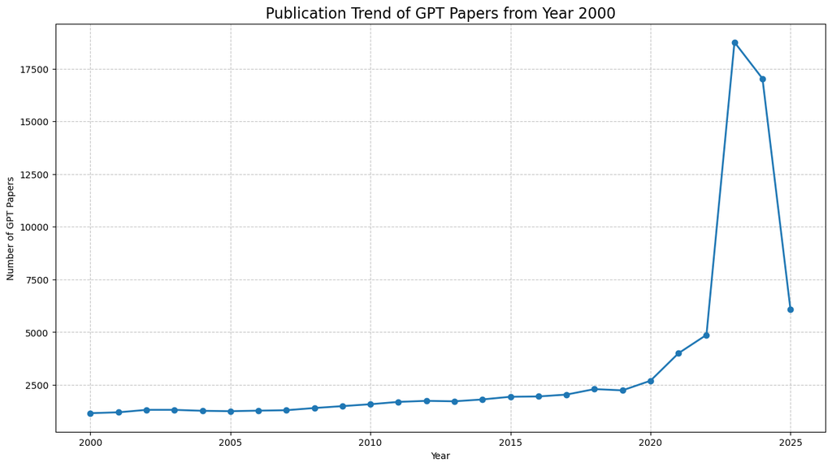

```python
# Filter for works related to GPT and was published after 2000
# aggregat by publication year
# Store the data in json format
url_gpt = "https://api.openalex.org/works?filter=from_publication_date:2000-01-01&search=gpt&group_by=publication_year"
search_gpt = requests.get(url_gpt).json()

# Save the json file
with open('search_gpt.json', 'w') as file:
    file.write(json.dumps(search_gpt, indent =4))

# Extract group by data from json response
group_year_gpt = search_gpt["group_by"]

# Convert to a dataframe
# rename columns
# make sure "year" is numeric
# sort by year
year_gpt = pd.DataFrame(group_year_gpt)
gpt_counts = year_gpt.rename(columns={"key": "year", "count": "num_publications"})
gpt_counts["year"] = pd.to_numeric(gpt_counts["year"])
gpt_counts = gpt_counts.sort_values("year")

# Plot the publication trend over time
plt.figure(figsize=(15, 8))
plt.plot(gpt_counts["year"], gpt_counts["num_publications"], marker="o", linewidth=2)
plt.xlabel("Year")
plt.ylabel("Number of GPT Papers")
plt.title("Publication Trend of GPT Papers from Year 2000", fontsize=16)
plt.grid(True, linestyle="--", alpha=0.7)
plt.show()
```

**Publication Trend of GPT Papers from Year 2000**

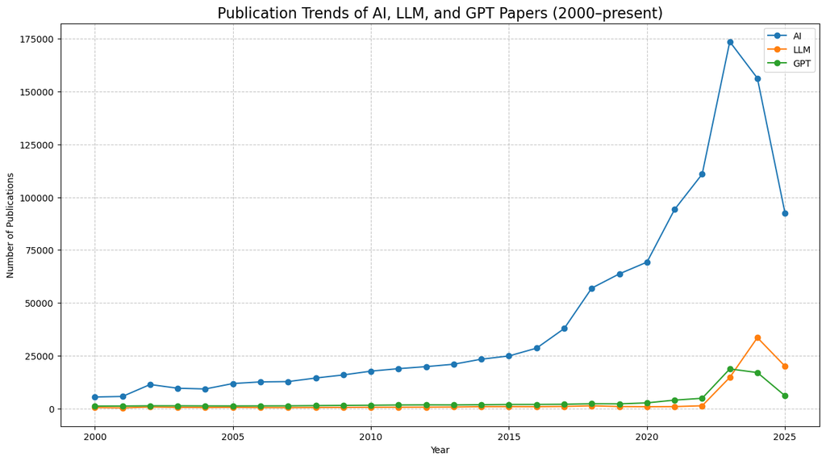

```python
# Figure size
plt.figure(figsize=(15, 8))

# Plot publication counts for AI, LLM, and GPT by year
plt.plot(year_counts["year"], year_counts["num_publications"], marker="o", label="AI")
plt.plot(llm_counts["year"], llm_counts["num_publications"], marker="o", label="LLM")
plt.plot(gpt_counts["year"], gpt_counts["num_publications"], marker="o", label="GPT")

# Add axis labels and title
plt.xlabel("Year")
plt.ylabel("Number of Publications")
plt.title("Publication Trends of AI, LLM, and GPT Papers (2000–present)", fontsize=16)

# Add label for each line
plt.legend()
plt.grid(True, linestyle="--", alpha=0.7)
plt.show()
```

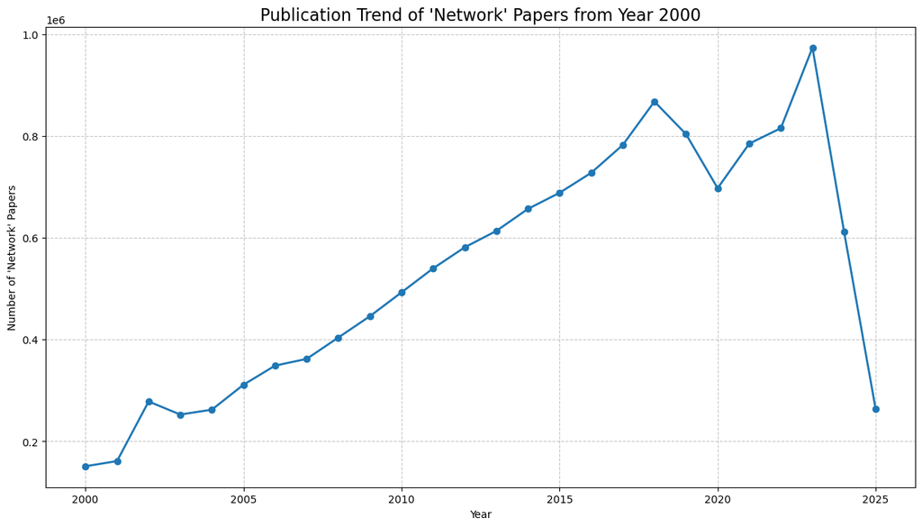

```python
# Filter for works related to "network" and published after 2000
# Aggregate by year
url_network = "https://api.openalex.org/works?filter=from_publication_date:2000-01-01&search=network&group_by=publication_year"
search_network = requests.get(url_network).json()

# Store the json file
with open('search_network.json', 'w') as file:
    file.write(json.dumps(search_network, indent=4))

# Extract group by information from json response
group_year_network = search_network["group_by"]

# Convert to dataframe, rename columns
# and sort by year
year_network = pd.DataFrame(group_year_network)
network_counts = year_network.rename(columns={"key": "year", "count": "num_publications"})
network_counts["year"] = pd.to_numeric(network_counts["year"])
network_counts = network_counts.sort_values("year")

# Plot the publication trend over time
plt.figure(figsize=(15, 8))
plt.plot(network_counts["year"], network_counts["num_publications"], marker="o", linewidth=2)
plt.xlabel("Year")
plt.ylabel("Number of 'Network' Papers")
plt.title("Publication Trend of 'Network' Papers from Year 2000", fontsize=16)
plt.grid(True, linestyle="--", alpha=0.7)
plt.show()
```

# Answer 4

From the combined figure, LLM and GPT related publications show very similar patterns, both experiencing rapid growth in 2022. This is intuitive, as GPT can be considered one of the key accomplishments of LLM research. After 2023, however, the two trends diverge: LLM related papers continue to increase rapidly, while GPT related publications show a slight decline, suggesting that attention may have shifted to other types of large language models. Compared with LLM and GPT works, AI related papers maintain dominance in volume, with steady growth from 2000 to 2016 and accelerated growth thereafter.